# Rで勾配降下法を可視化する

UPDATE: 2022-09-04 20:55:22

# はじめに

このノートではRを使ってRで勾配降下法を可視化する方法をまとめておく。下記を大いに参考にさせていただいた。

- [2 Gradient Descent](https://egallic.fr/Enseignement/ML/ECB/book/gradient-descent.html)

## 2次元の勾配降下法

まずは必要なライブラリを読み込んでおく。

```r
library(tidyverse)
library(numDeriv)
library(gganimate)
library(plot3D)
```

関数$f(x)= x^4 - 3x^3 + x^2 + 3x + 1$を使って、勾配法を可視化する。

```r
x <- seq(-1, 2, by = .01)
f <- function(x) x^4 - 3*x^3 + x^2 + 3*x + 1
y <- f(x)
df <- tibble(x = x, y = y)
df
```

```
## # A tibble: 301 × 2
##        x     y
##    <dbl> <dbl>
##  1 -1     3
##  2 -0.99  2.88
##  3 -0.98  2.77
##  4 -0.97  2.65
##  5 -0.96  2.55
##  6 -0.95  2.44
##  7 -0.94  2.34
##  8 -0.93  2.24
##  9 -0.92  2.14
## 10 -0.91  2.04
## # … with 291 more rows
## # ℹ Use `print(n = ...)` to see more rows
```

関数を可視化するスクリプト。

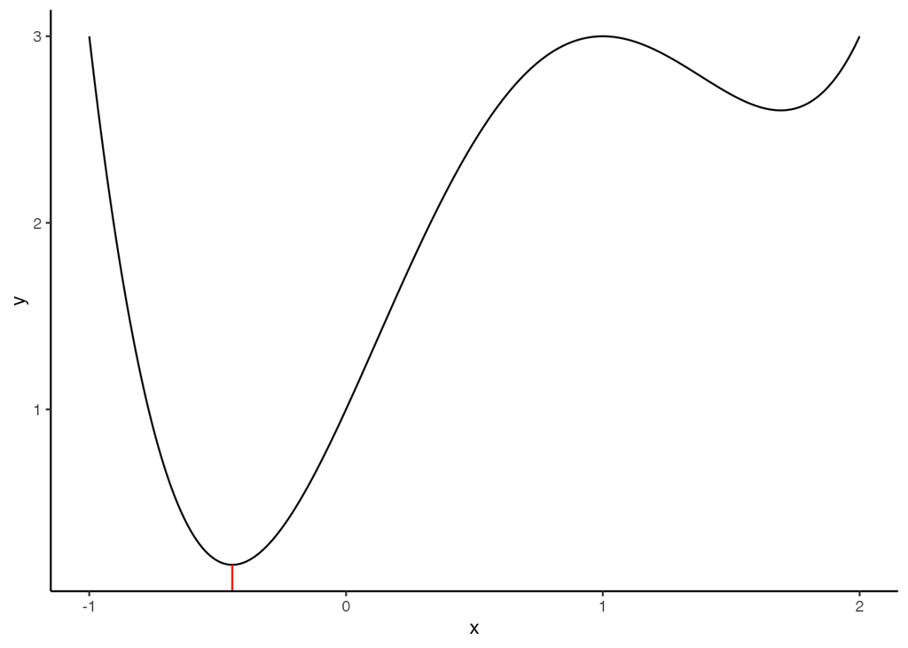

```r
ggplot(df, aes(x, y)) +
  geom_line() +
  geom_segment(
    data = tibble(x = -0.443, xend = -0.443,y = -Inf, yend = f(-0.443)),
    aes(x = x, y=y, xend=xend, yend = yend), col = "red"
    ) +
  theme_classic()
```

`x_0 = 0.5`を初期値として勾配法を可視化する。

```r
x_0 <- 0.5
f(x_0)
```

```
## [1] 2.4375
```

グラフに初期値をプロットする。

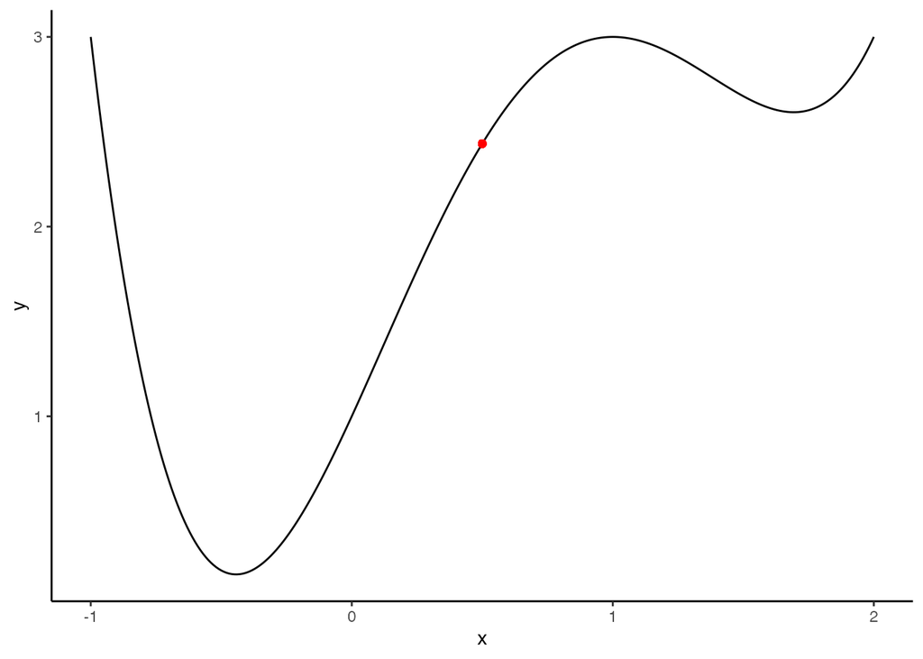

```r
ggplot(df, aes(x, y)) +
  geom_line() +
  geom_point(x = x_0, y = f(x_0), colour = "red") +
  theme_classic()
```

$x^{4}-3x^{3}+x^{2}+3x+1$を$x$について微分して導関数を使って$x = 0.5$の値を計算する

$$\begin{eqnarray}
\displaystyle \frac{d}{dx}(x^{4} - 3x^{3} + x^{2} + 3x + 1) = 4 x^3 - 9
x^2 + 2 x + 3 \\
\end{eqnarray}$$

傾きは`numDeriv`パッケージの`grad`関数で計算できる。

```r
# 上記の導関数にx=0.5の値を代入した結果
grad <- grad(func = f, x = c(x_0))
grad
```

```
## [1] 2.25
```

直線の方程式を式変形すれば、切片を計算できるので、切片を計算する。

```r
# f(x) = intercept + grad * x_0を変形する
intercept <- -grad*x_0 + f(x_0)
intercept
```

```
## [1] 1.3125
```

$x = 0.5$における傾きを可視化する。この点での傾きが正なので、左側にすすめる。

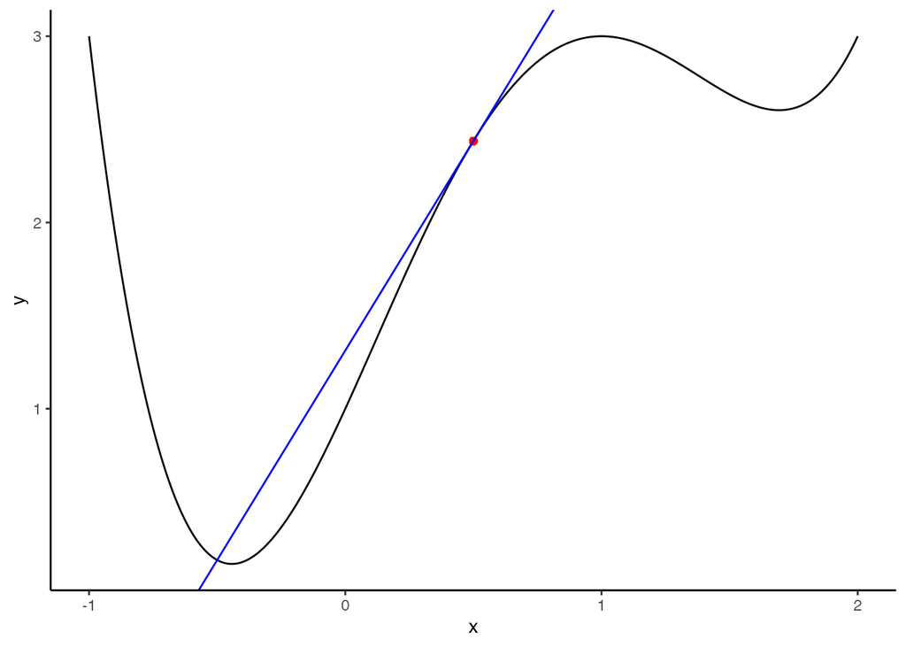

```r
ggplot(df, aes(x, y)) +
  geom_line() +
  geom_point(x = x_0, y = f(x_0), colour = "red") +
  geom_abline(slope = grad, intercept = intercept, colour = "blue") +
  theme_classic()
```

更新した値を使って、傾きと切片を求めると、傾きがまだ正なので、左に進めていく。

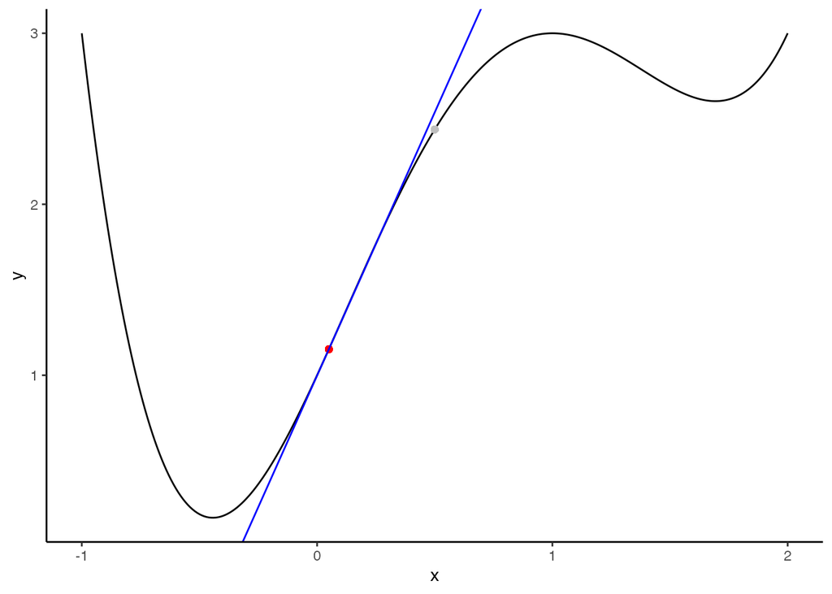

```r
learning_rate <- 0.2
x_1 <- x_0 - learning_rate * grad
grad_x_1 <- grad(func = f, x = c(x_1))
intercept_x_1 <- -grad_x_1*x_1 + f(x_1)

ggplot(df, aes(x, y)) +
  geom_line() +
  geom_point(x = x_0, y = f(x_0), colour = "gray") +
  geom_point(x = x_1, y = f(x_1), colour = "red") +
  geom_abline(slope = grad_x_1, intercept = intercept_x_1, colour = "blue") +
  theme_classic()
```

これを繰り返す。傾きが負になったので、次は右にすすめる。

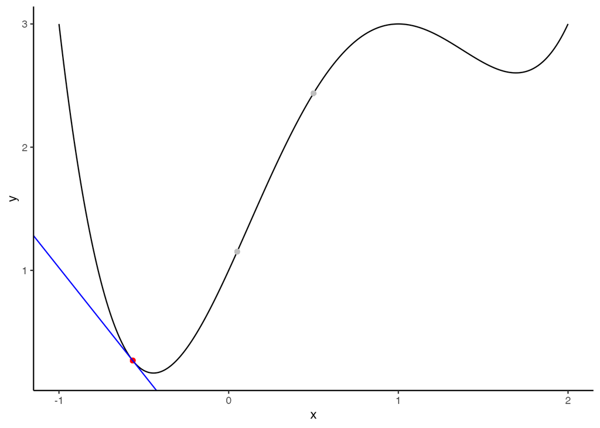

```r
x_2 <- x_1 - learning_rate * grad_x_1
grad_x_2 <- grad(func = f, x = c(x_2))
intercept_x_2 <- -grad_x_2*x_2 + f(x_2)

ggplot(df, aes(x, y)) +
  geom_line() +
  geom_point(x = x_0, y = f(x_0), colour = "gray") +
  geom_point(x = x_1, y = f(x_1), colour = "gray") +
  geom_point(x = x_2, y = f(x_2), colour = "red") +
  geom_abline(slope = grad_x_2, intercept = intercept_x_2, colour = "blue") +
  theme_classic()
```

これを繰り返すことで、関数の最小値を計算するアルゴリズムが勾配法。

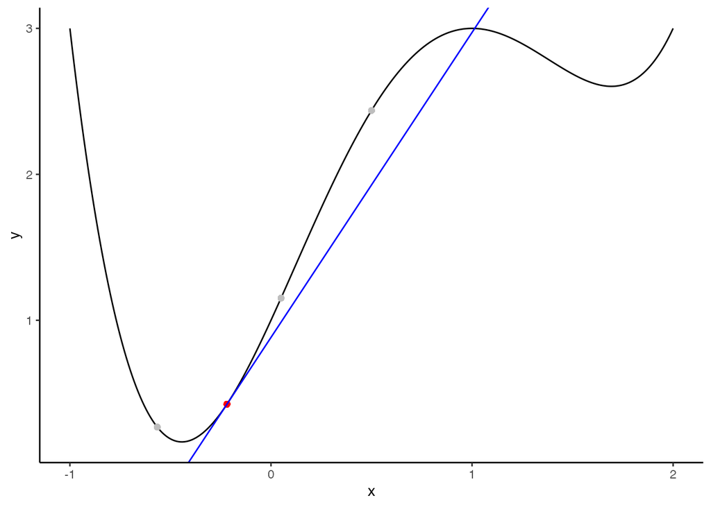

```r
x_3 <- x_2 - learning_rate * grad_x_2
grad_x_3 <- grad(func = f, x = c(x_3))
intercept_x_3 <- -grad_x_3*x_3 + f(x_3)

ggplot(df, aes(x, y)) +
  geom_line() +
  geom_point(x = x_0, y = f(x_0), colour = "gray") +
  geom_point(x = x_1, y = f(x_1), colour = "gray") +
  geom_point(x = x_2, y = f(x_2), colour = "gray") +
  geom_point(x = x_3, y = f(x_3), colour = "red") +
  geom_abline(slope = grad_x_3, intercept = intercept_x_3, colour = "blue") +
  theme_classic()
```

これをアニメーションで可視化する。まずは可視化用のデータを作るために勾配の繰り返し処理を行う。

```r
iter <- 200
# tolerance <- 10^-6
eta <- 0.01

x_1 <- 0.5
# To keep track of the values through the iterations
x_1_values <- x_1
y_1_values <- f(x_1)
gradient_values <- NULL
intercept_values <- NULL

for(i in 1:iter){
  # Steepest ascent:
  grad <- grad(func = f, x = c(x_1))

  intercept_value <- -grad*x_1 + f(x_1)
  # Keeping track
  gradient_values <- c(gradient_values, grad)
  intercept_values <- c(intercept_values, intercept_value)

  # Updating the value
  x_1 <- x_1 - eta * grad
  y_1 <- f(x_1)

  # Keeping track
  x_1_values <- c(x_1_values, x_1)
  y_1_values <- c(y_1_values, y_1)

  # Stopping if no improvement (decrease of the cost function too small)
  # if(abs(y_1_values[i] - y_1 < tolerance)) break

}
```

可視化用のデータフレームを作成する。

```r
df_plot <- tibble(
  iter = 1:iter,
  xx = seq(-1, 2, length.out = iter),
  x_1 = x_1_values[-length(x_1_values)],
  y = f(x_1),
  gradient = gradient_values,
  intercept = intercept_values
)
head(df_plot)
```

[output not shown]

勾配降下法をアニメーションで可視化する。

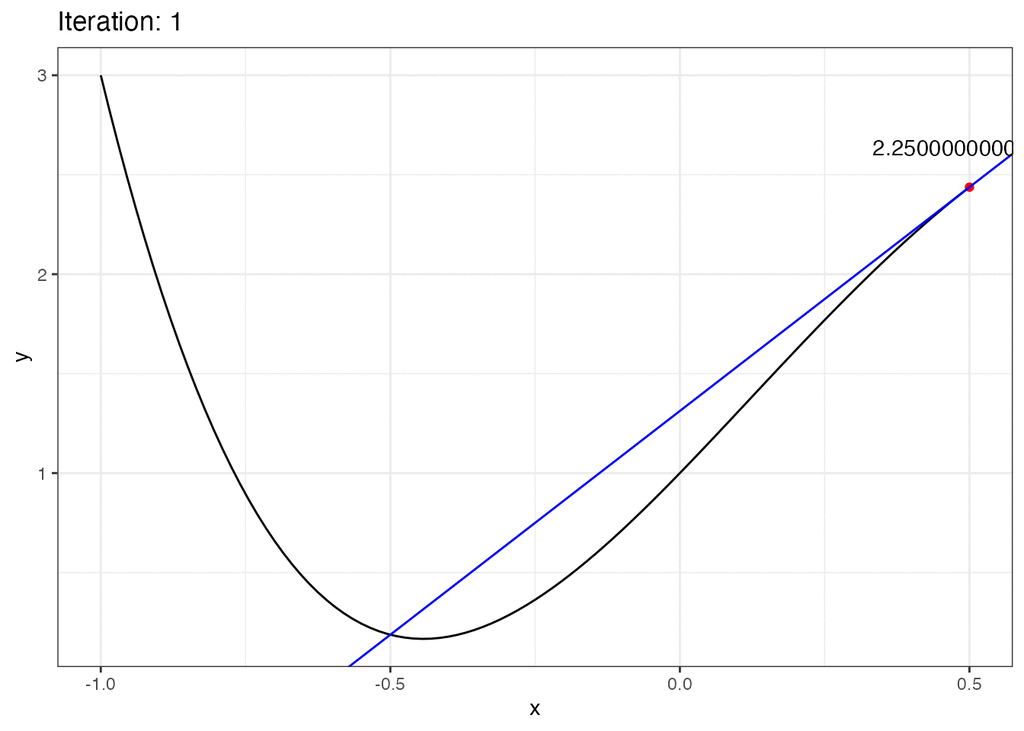

```r
ggplot(df_plot %>% filter(iter < 100)) +
  stat_function(fun = f, aes(xx)) +
  geom_point(aes(x = x_1, y = y), colour = "red") +
  geom_abline(aes(slope = gradient, intercept = intercept), colour = "blue") +
  geom_text(aes(x = x_1, y = y + 0.2, label = gradient)) +
  theme_bw() +
  transition_time(iter) +
  labs(title = "Iteration: {frame_time}", x = 'x') +
  ease_aes('elastic-in')
```

## 3次元の勾配降下法

次は3次元の勾配降下法を可視化する。関数$f(x)=x^2_{1} + x^2_{2}$を可視化する。

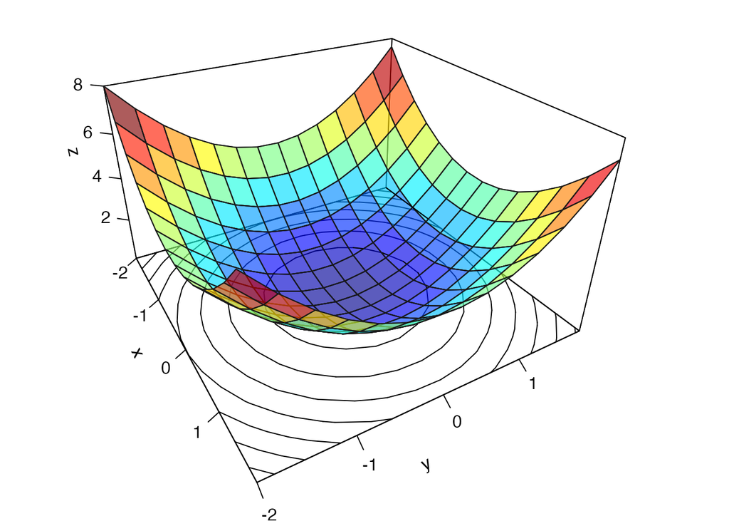

```r
x_1 <- x_2 <- seq(-2, 2, by = 0.3)
z_f <- function(x_1,x_2) x_1^2+x_2^2
z <- outer(x_1, x_2, z_f)

par(mar = c(1, 1, 1, 1))
flip <- 1 # 1 or 2
th = c(-300, 120)[flip]
pmat <- persp3D(x = x_1, y = x_2, z = z,
                colkey = FALSE, # 凡例
                contour=TRUE, # 等高線
                ticktype = "detailed", # 目盛り
                asp = 1, phi = 30, theta = th,
                border = "gray10", alpha = 0.4,
                expand = .6, # 横広げる
                axes = TRUE, box = TRUE
                )
```

初期値を$X=(1.5, 1.5)$とする。赤色の点をプロットする。

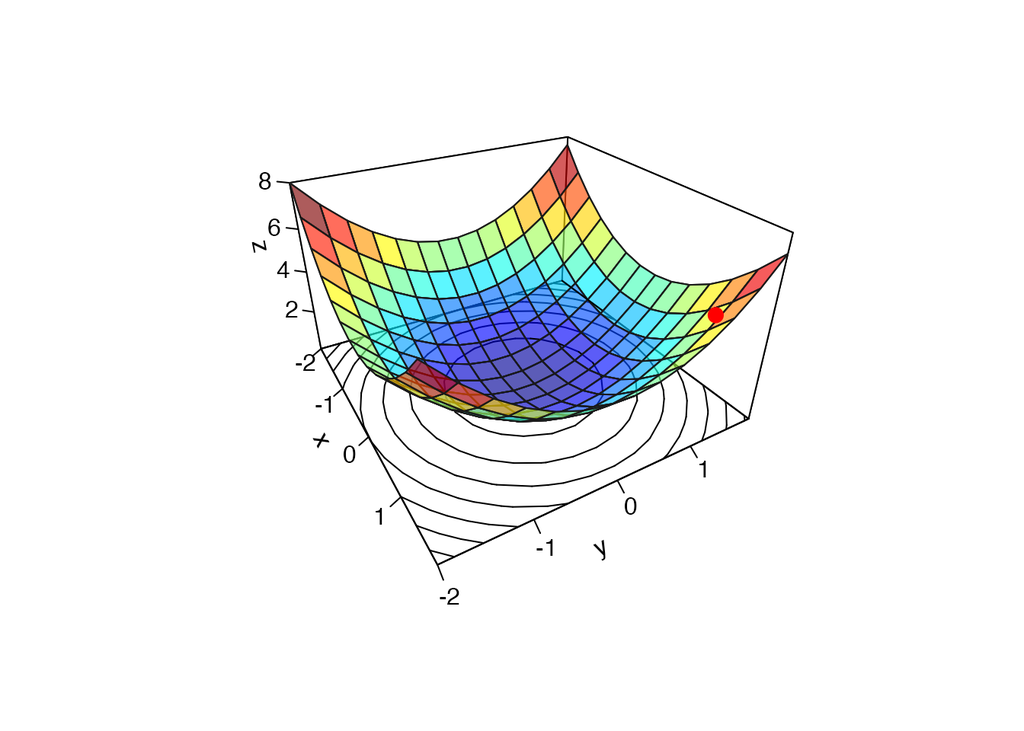

```r
theta <- c(x_1 = 1.5, x_2 = 1.5)

zz <- z_f(theta[["x_1"]], theta[["x_2"]])
new_point <- trans3d(theta[["x_1"]], theta[["x_2"]], zz, pmat = pmat)

pmat <- persp3D(
  x = x_1, y = x_2, z = z,
  colkey = FALSE, # 凡例
  contour = TRUE, # 等高線
  ticktype = "detailed", # 目盛り
  asp = 1,
  phi = 30,
  theta = th,
  border = "gray10",
  alpha = 0.4,
  expand = 0.6, # 横広げる
  axes = TRUE,
  box = TRUE
)
points(new_point,　pch = 20, col = "red", cex = 2)
```

更新式は下記の通りなので、

$$\begin{eqnarray}
\begin{bmatrix}
x^{(t+1)}_{1} \\
x^{(t+1)}_{2}
\end{bmatrix}
=
\begin{bmatrix}
x^{(t)}_{1} \\
x^{(t)}_{2}
\end{bmatrix}
-
\eta
\begin{bmatrix}
\frac{ \partial f }{ \partial x_{1} }(x^{(t)}_{1}, x^{(t)}_{2}) \\
\frac{ \partial f }{ \partial x_{2} }(x^{(t)}_{1}, x^{(t)}_{2})
\end{bmatrix}
\end{eqnarray}$$

初期値を更新するために勾配を計算する。

```r
learning_rate <- 0.1
z_f_to_optim <- function(theta){
  x_1 <- theta[["x_1"]]
  x_2 <- theta[["x_2"]]
  x_1^2 + x_2^2
}
grad <- grad(func = z_f_to_optim, x = theta)
grad
```

```
## [1] 3 3
```

初期値を更新する。

```r
updated_x_1 <- theta[["x_1"]] - learning_rate * grad[1]
updated_x_2  <- theta[["x_2"]] - learning_rate * grad[2]
updated_theta <- c(x_1 = updated_x_1, x_2 = updated_x_2)
updated_theta
```

```
## x_1 x_2
## 1.2 1.2
```

新しい`z`を計算する。

```r
updated_zz <- z_f(updated_theta[["x_1"]], updated_theta[["x_2"]])
new_point_2 <- trans3d(updated_theta[["x_1"]],
                       updated_theta[["x_2"]],
                       updated_zz,
                       pmat = pmat)
new_point_2
```

```
## $x
## [1] 0.2423082
##
## $y
## [1] -0.07318442
```

これを使って、更新した点をプロットする。

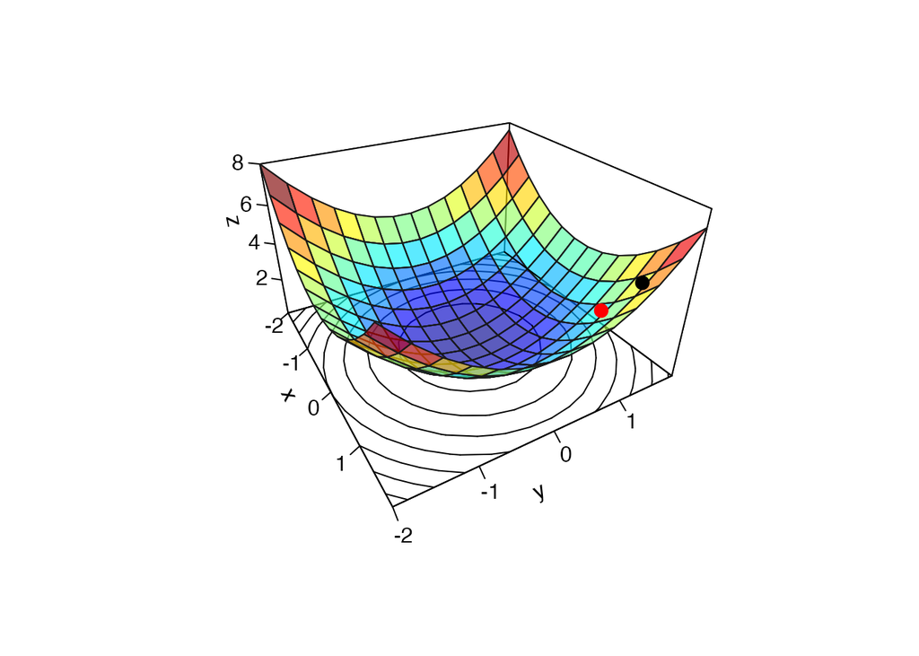

```r
pmat <- persp3D(
  x = x_1, y = x_2, z = z,
  colkey = FALSE,  # 凡例
  contour = TRUE,  # 等高線
  ticktype = "detailed",  # 目盛り
  asp = 1,
  phi = 30,
  theta = th,
  border = "gray10",
  alpha = 0.4,
  expand = 0.6,  # 横広げる
  axes = TRUE,
  box = TRUE
)
points(new_point,pch = 20,col = "black", cex=2)
points(new_point_2,pch = 20,col = "red", cex=2)
```

これを2次元のときと同じ用に、繰り返して勾配法を実行する。

```r
eta <- 0.1
iter <- 50
#tolerance <- 10^-5

# Starting values
theta <- c(x_1 = 1.5, x_2 = 1.5)

# To keep track of what happens at each iteration
theta_values <- list(theta)
y_values <- z_f_to_optim(theta)

for(i in 1:iter){
  # Steepest ascent
  grad <- grad(func = z_f_to_optim, x = theta)

  # Updating the parameters
  updated_x_1 <- theta[["x_1"]] - eta * grad[1]
  updated_x_2  <- theta[["x_2"]] - eta * grad[2]
  theta <- c(x_1 = updated_x_1, x_2 = updated_x_2)

  # Keeping track
  theta_values <- c(theta_values, list(theta))

  # Checking for improvement
  y_updated <- z_f_to_optim(theta)
  y_values <- c(y_values, y_updated)

  # if(abs(y_values[i] - y_updated) < tolerance) break
}
```

勾配法の実行過程を可視化する。

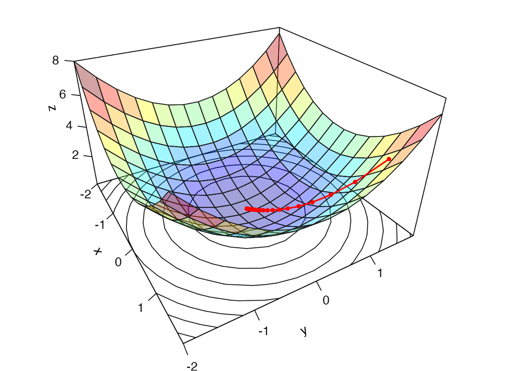

```r
par(mar = c(1, 1, 1, 1))
flip <- 1 # 1 or 2
th = c(-300,120)[flip]
pmat <- persp3D(
  x = x_1, y = x_2, z = z,
  colkey = FALSE, # 凡例
  contour = TRUE, # 等高線
  ticktype = "detailed", # 目盛り
  asp = 1,
  phi = 30,
  theta = th,
  border = "gray10",
  alpha = 0.2,
  expand = 0.6, # 横広げる
  axes = TRUE,
  box = TRUE
)

xx <- map_dbl(theta_values, "x_1")
yy <- map_dbl(theta_values, "x_2")
zz <- y_values
new_point <- trans3d(xx, yy, zz, pmat = pmat)
lines(new_point, pch = 20, col = "red", cex = 1, lwd = 2)
points(new_point, pch = 20, col = "red", cex = 1)
```

アニメーションさせる場合は下記を利用する。

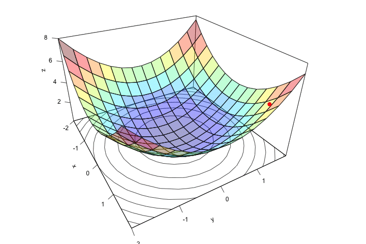

descent_2D_sphere

```r
# library(animation)
# saveGIF({
#   for (j in c(rep(1, 5), 2:(i - 1), rep(i, 10))) {
#     par(mar = c(1, 1, 1, 1))
#     flip <- 1 # 1 or 2
#     th = c(-300, 120)[flip]
#     pmat <- persp3D(
#       x = x_1, y = x_2, z = z,
#       colkey = FALSE, # 凡例
#       contour = TRUE, # 等高線
#       ticktype = "detailed", # 目盛り
#       asp = 1,
#       phi = 30,
#       theta = th,
#       border = "gray10",
#       alpha = 0.2,
#       expand = 0.6, # 横広げる
#       axes = TRUE,
#       box = TRUE
#     )
#
#     xx <- map_dbl(theta_values, "x_1")[1:j]
#     yy <- map_dbl(theta_values, "x_2")[1:j]
#     zz <- y_values[1:j]
#     new_point <- trans3d(xx, yy, zz, pmat = pmat)
#     lines(
#       new_point,
#       pch = 20,
#       col = "red",
#       cex = 2,
#       lwd = 2
#     )
#     points(new_point,
#            pch = 20,
#            col = "red",
#            cex = 2)
#   }
#
# },
# movie.name = "~/Desktop/descent_2D_sphere.gif",
# interval = 0.01,
# ani.width = 720,
# ani.height = 480)
```